# Análisis de emociones de ‘El cumpleaños de la infanta’

Erick_Kauffmann-Aivy_Masís

2025-06-30

## Introducción

Este documento presenta un análisis de sentimientos aplicado al cuento “El cumpleaños de la infanta” de Oscar Wilde, utilizando herramientas de procesamiento de texto en R. A partir de distintas visualizaciones, como la nube de palabras, el gráfico de polaridad, el conteo de emociones, el arco emocional y la red de palabras frecuentes, se busca explorar el tono emocional del texto y las principales temáticas que lo atraviesan. El objetivo no es solo identificar qué emociones predominan, sino también comprender cómo Wilde construye un relato lleno de contrastes, donde la belleza y la crueldad conviven, y donde lo infantil se mezcla con lo trágico. A través de estas técnicas de visualización, se revela una estructura narrativa llena de simbolismo y emociones complejas que aportan nuevas formas de interpretar la obra.

Algunos de los gráficos generados se le aplicó la limitación a cierto número de palabras para lograr una mejor visualización de la gráfica y poder realizar una mejor interpretación de emociones, contexto y flujo de los acontecimientos.

## Nubes de palabras

La nube de palabras generada a partir del cuento “El cumpleaños de la infanta” muestra que hay ciertos términos que se repiten con mucha frecuencia y que están directamente relacionados con los elementos centrales del relato. La palabra más destacada es “infanta” lo cual no sorprende porque ella es la protagonista de la historia y todo gira alrededor de su cumpleaños y sus emociones. También aparecen con bastante fuerza palabras como “enanito”, “niños”, “bosque”, “monstruo” y “palacio”. Estas nos hablan tanto del contexto del cuento como de los elementos más simbólicos o emocionales que se van desarrollando a lo largo del texto.

Es interesante cómo se combinan palabras que remiten al lujo, como “plata”, “reina” y “trono”, con otras que muestran ternura, naturaleza como “corazón”, “flores” y “labios”.

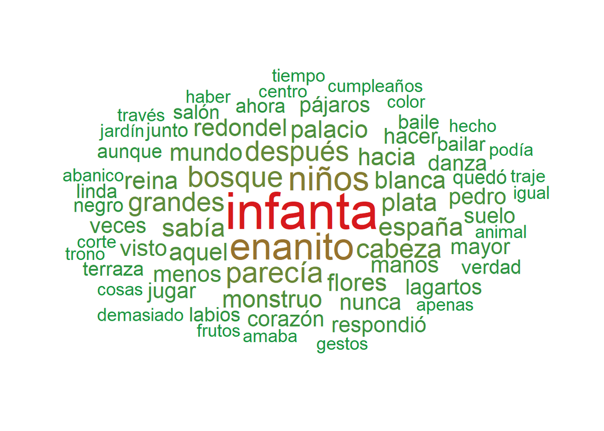

## Análisis de polaridad

El gráfico de polaridad muestra cómo varía la carga emocional del cuento a lo largo de sus oraciones. En este caso, se utilizó el método Bing para clasificar las oraciones como positivas, negativas o neutras. Lo que más llama la atención es que la mayor parte del texto se mueve entre polaridades negativas o neutras, con pocos picos realmente positivos. En varias secciones hay una caída clara hacia valores negativos, lo que indica la presencia de palabras cargadas emocionalmente hacia la tristeza, la decepción o el rechazo. Esto es coherente con el tono general del cuento, que a pesar de tener momentos visuales muy bonitos o festivos, tiene un fondo melancólico y hasta cruel, especialmente relacionado con el personaje del enanito y su interacción con la infanta. También se pueden ver algunos picos positivos, pero son esporádicos y no duran mucho. Esto sugiere que la historia tiene breves momentos de alegría o ternura, pero rápidamente vuelven a un tono más serio o doloroso. En resumen, el gráfico respalda esa dualidad emocional del cuento: por fuera todo parece colorido y encantador, pero por dentro hay una tristeza profunda que atraviesa todo el relato.

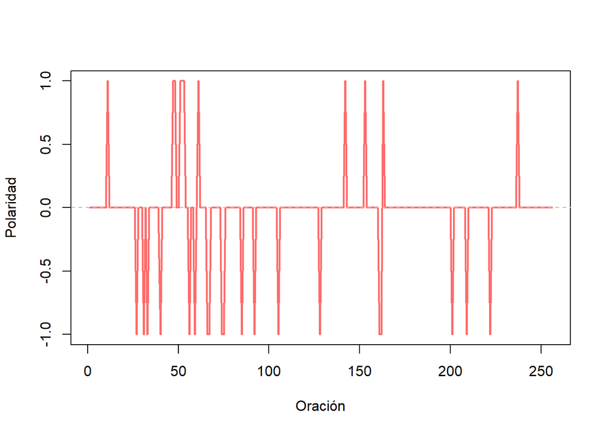

## Conteo de emociones

Este gráfico muestra la distribución de emociones en el cuento, utilizando el léxico NRC. Lo primero que salta a la vista es que hay una cantidad bastante balanceada de palabras positivas y negativas, con una leve ventaja para las positivas. Sin embargo, la diferencia no es tan marcada, lo que refleja la ambigüedad emocional del cuento, hay momentos alegres, pero también muchos otros que transmiten tristeza. Entre las emociones específicas, se destacan la tristeza, la confianza, el miedo y la alegría. Es interesante que la tristeza esté más presente que la alegría, lo cual tiene mucho sentido considerando el giro emocional que da la historia, especialmente hacia el final, cuando el enanito se da cuenta de la burla y lo que eso significa para él. La presencia notable de confianza y miedo sugiere que hay cierta tensión narrativa entre sentirse seguro o en armonía, como lo hace el enanito mientras baila, por ejemplo, y el miedo que se manifiesta en momentos de conflicto o soledad. También se observan emociones como la ira, la sorpresa y el disgusto, aunque en menor proporción. Esto podría estar ligado a cómo se presentan ciertos personajes, como don Pedro o incluso las flores que reaccionan negativamente al enanito, así como los eventos que rompen la armonía del entorno en apariencia festivo. En general, el gráfico confirma que el cuento no es simplemente una historia infantil o alegre, sino que está cargado de emociones complejas, muchas veces contradictorias.

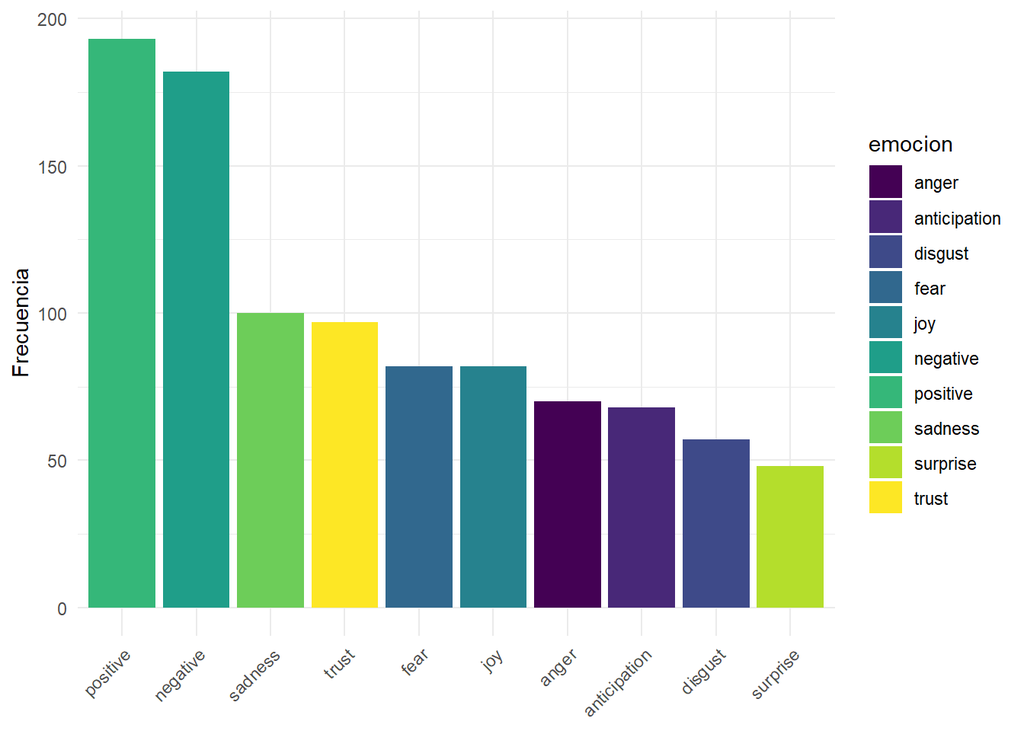

## Arco emocional

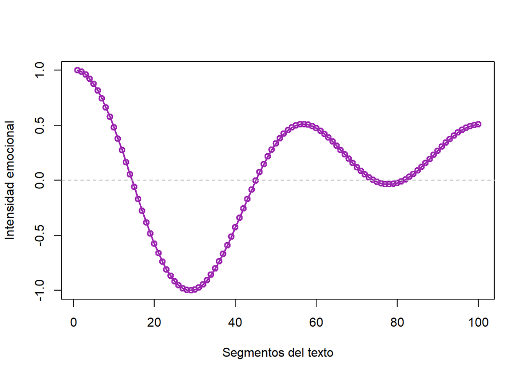

## Red de palabras

La red de palabras más frecuentes muestra cómo ciertos términos aparecen juntos de forma repetida a lo largo del cuento. Visualmente, se nota que hay muchas conexiones entre las palabras, lo que indica que el texto tiene una estructura narrativa muy robusta, con temas que se entrelazan constantemente. Palabras como “infanta”, “enanito”, “niños”, “palacio”, “bosque” y “flores” están bien conectadas con otras, lo cual tiene sentido porque son parte del núcleo temático del cuento. Estas conexiones refuerzan la imagen de un entorno natural y equilibrado, donde se mezclan lo inocente con lo cruel, lo tierno con lo simbólico. También se ven palabras como “monstruo”, “parecía”, “cabeza” o “rosa”, que dan pistas sobre las metáforas o las descripciones físicas/ y emocionales que el autor usa para construir contrastes. Muchas de estas palabras están cargadas de significado visual o simbólico.

Por lo que esta red refleja cómo el cuento no solo gira alrededor de ciertos personajes o lugares, sino también de sensaciones y percepciones que se repiten y se conectan entre sí, dando como resultado un estilo narrativo visual y emotivo.

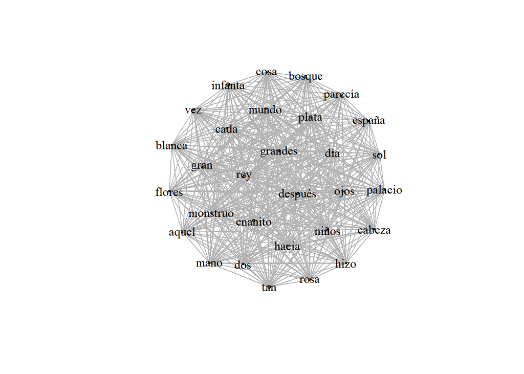